# `codeblitz001`: Get to know your new labmate, `Github`

## Background

In the Landscape Ecology Lab, we study disturbance, forest dynamics, integrating field work and remote sensing. Much of this work involves coding, analyzing large datasets, developing reproducible workflows, and building methods that can be shared across projects. Coding is often learned and practiced in isolation. Our **Code Blitzes** create a space to code together, so we can sharpen skills, solve problems as a team, and strengthen the collaborative spirit of our lab.

- Provide training in collaborative coding skills in `R` and GitHub that improve reproducibility and teamwork across lab projects.
- Strengthen our lab network by creating shared experiences for junior and senior members.
- Advance research capacity in disturbance ecology, LiDAR, and remote sensing through shared tools, workflows, and problem-solving.

In this first Code Blitz, we’ll focus on getting everyone set up and making their first contributions in GitHub. By the end of the session, each lab member will have contributed to a shared project that forms the foundation of a collaborative website.

[figure not shown]

**AI generated image depecting what our group is up to today. Aren’t we a handsome group?**

## Learning objectives:

For this code blitz, we’ll each contribute portions of a lab website that features our favorite field sites. But you can also do you favorite vacation, hiking spot, etc. By the end of the blitz, you will

- get to know new folks in the lab
- get comfortable with collaborative contributions using Github and R
- get comfortable learning syntax for a new coding language

Specifically we will

1. Create GitHub accounts and install the necessary tools.
2. Practice the basic workflow: branch, clone, edit, commit, and push.
3. Contribute text using Markdown to build a shared lab website.

## Pre-Work

Prior to our first meeting, please complete the following tasks:

1. [Setup a Github account](https://github.com/signup). Note that you may have to verify your account and possibly setup a dual-authentication. You can actually do this in your DUO app that you use for Jones Center authentication
2. Make sure you have `RGUI` and `Rstudio` installed on your computer. You can find some instructions [here](https://rpubs.com/premisa/714217).
3. install `gitbash` on your computer. In Windows open the Command Prompt by clicking start and typing `cmd`. When the command prompt is open type `winget install --id Git.Git -e --source winget`

## Assigned teams

We’ll all complete the work, but let’s still work in groups so that you have a go-to team to ask questions. We will create Teams Rooms for you to meet privately, share code, and answer questions. Go to your team first to ask questions. If the issue persists, bring it to the larger group.

| Team name | Room Name | Person 1 | Person 2 | Person 3 | Person 4 |
| --- | --- | --- | --- | --- | --- |
| Ferns | Room 1 | Jeff | Tristan | Latonya | Jingting |
| Saplings | Room 2 | Khanh | Tanner | Carly | Nathan |
| Rhizomes | Room 3 | Nicole | Morne | Leah | Lain |

## Instructions Part 1:

The instructions are intentionally vague as this is the first time trying this! We’ll try to answer specific questions in person but you should

1. **Clone** the code blitz repository and Open the template assigned for you

[figure not shown]

*Click the green **Code** button. In the Local drop-down, copy the HTTPS link.*

[figure not shown]

*In RStudio, choose File/New Project/Version Control/Git. Paste the repo URL and the project directory name will auto-populate. Save the project wherever you usually save your Rprojs.*

2. *Create a new branch* with your name (e.g., `jeff`)

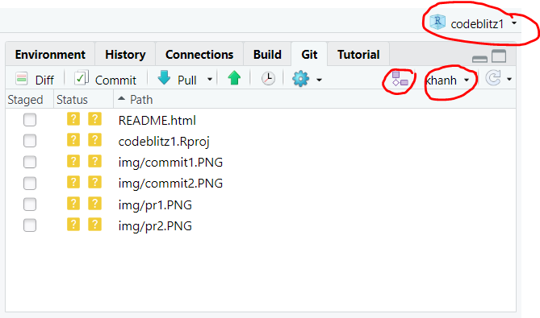

*Make sure you’re in the right Rproj (indicated by the blue R cube at the top right corner). In the Git tab, click on the purple icon to create your branch. Once your branch is created, you should be automatically switched to work on it. Double check to make sure the branch name indicates so.*

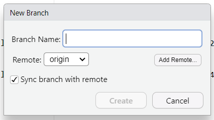

*Name your branch with your name or something we can easily recognize. Don’t change anything else.*

3. Make a new R markdown (e.g., `jeff.Rmd`) document to make a profile.
4. Make a profile of your **favorite field site**, vacation spot, or hiking trail. The important part is that its a real place that you know well and possibly have photos of. But this is all just practice, so whatever you want is fine. Could be imaginary I suppose.
5. **Using the Markdown language**, fill in the fill in the requested information about your selected site. You’ll need to insert photos, captions, format text, links, bullets etc. See here for a [Markdown Syntax Cheat Sheet](https://www.markdownguide.org/cheat-sheet/)
6. You will see a template Rmd file from Khanh where you can follow along and use as an example. Each section denotes header levels for your profile. Fill out each section, using markdown syntax to add complexity complexity.
7. **You will include some some false information and errors in your profile. This is so that we can collaboratively edit later!**
8. When you are finished, be sure to **Commit the changes to your branch**

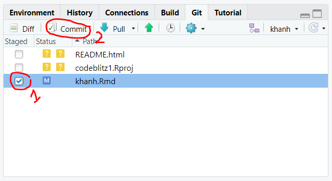

*Stage your commit by checking the box (1), then click the Commit button*

[figure not shown]

*Write the commit message (without a message, the system won’t let you commit) (1), click the Commit button (2), then click the Push button (3) to commit the changes from your local to remote repo*

9. Open a pull request from your branch to `main` which we will merge

[figure not shown]

*After you have successfully committed and pushed, there should be an automatic notification in yellow in GitHub telling you to **Compare & pull request**. Click on it, or manually create a PR by clicking on the **Pull requests** tab above the repo.*

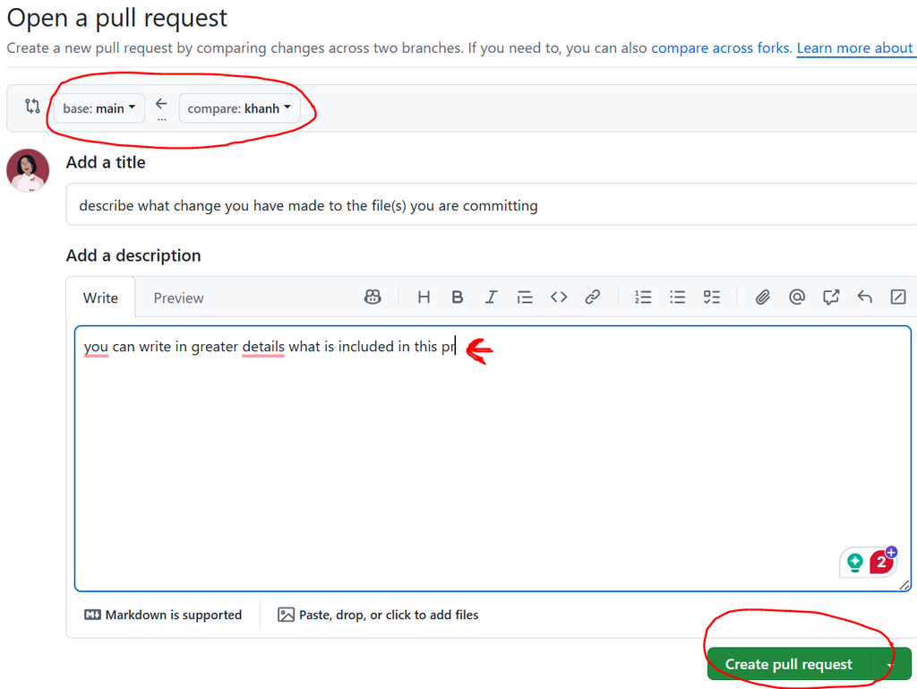

*Be sure to set **base: main** and **compare: [your branch]**. Option to modify your PR’s title and add a description. Click **Create pull request** once you are happy with everything.*

10. **YOU ARE ALL SET FOR NOW!** Once merged, your profile will eventually appear here: https://landeco-jonesctr.github.io/codeblitz1/ (after Khanh updates the yml file and knits the website together).

```
# Name
## Biography
## Favorite field site
## Photo gallery
## Resources
## Map of field site
```

### `# Name`

Your name, duh, note the **Header level 1**, indicated by a single `#`

### `## Biography`

- Note the **Header level 2** indicated by the double `##`.
- Write a short 100 word biography about yourself, background, and hobbies.
- Insert a photo you may have to upload it to the `img/` directory or link directly from a webpage. Specify a caption and adjust the size of the image
- Insert one *obviously false* statement about you in the biography.

## `## Favorite field site`

- Write a brief description of your site including location, features, and other information.
- Include a **bulleted list** pertaining to your site. It could be a list of things to do there, features that you like, or a list of your favorite plants located there.
- Insert typo in your list for a partner to fix.

## `## Photo gallery`

- Insert 2-3 photos representative of your field site. They could be a representative plant or a photo from your visit.
- Be sure to include a descriptive caption in each one
- Add a typo in one image path so that the link is broken. Bonus: Make one of the photos a thumbnail with a hyperlink!

## `## Resources`

- Add three references or links to a resource related to your selected field site. It may be a field guide, map, article, or data source.
- Make sure they contain a hyperlink to an outside webpage

## `## Code`

- Embed a chunk of `R` code that creates a map of your field site.

`{r warning=FALSE} library(leaflet) leaflet() %>% addTiles() %>% addMarkers(lng = -71.297210, lat = 44.055972, popup = "Barlett Experimental Forest")`

- Include a function in R that calculates tree basal area from a vector of tree dbh’s from your site. The function should be able to
  - Deal with missing dbh values
  - work for multiple plot sizes

```
dbh = c(35, 23, 12, NA, 8) # in cm
plot_area = 0.1 #in ha
```

- To display a chunk of `R` code, you can use the following format, offset by three backticks `` ``` ``. (See `khanh.Rmd` for an example of formatting R codes in Rmd.)

`{r} myFunction = function(dbh, plot_area) { #my code return(basal_area) }`

## Instructions – Homework Part 2:

Now that you’ve practiced committing to your own branch, we will try a common workflow: Editing someone elses code

1. Pull the new merged repo onto your computer
- If you’re on a new computer or want to start fresh, see instructions above about how to clone the current repo as you did in part 1.
- If you’re using the same computer and still have the old files, open Codeblitz1.Rproj
  - Switch back to the main local branch
  - Use **PULL** to update your local copy of the main branch to the current copy

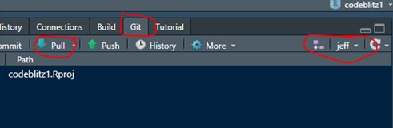

  - **Note:** You may get an error about some files being overwritten. This means you made some local changes to unmerged files on the repo. Find the files or directories mentioned and delete them. Don’t worry they will be restored to the consensus version when you sync! You probably have to delete a ‘site_libs’ folder if you used the knit function at some point.
  - You may need to click the refresh button to see the files as they come in

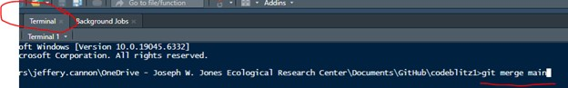

2. Once everything is synchronized, switch back to your personal branch
3. Your personal branch will need to get the latest updates from the main branch. To do this, Go to the Terminal tab and type `git merge main`

[figure not shown]

- Your branch is now up-to-date with the main branch and ready to suggest new changes!
4. Open the `.Rmd` of your assigned profile from the files list, and make some edits!

| Edit Assignments |
| --- |
| Khanh ↔︎ Tanner |
| Nicole ↔︎ Morne |
| Leah ↔︎ Lain |
| Carly ↔︎ Nathan |
| Jeff edits → Jingting, Jingting edits → Tristen, Tristen edits → Jeff |

5. Correct typos and incorrect statements, and fix any broken links or code. Contact your partner if you are unsure about how to fix anything!
6. Save your changes to the file
7. Commit your changes when you are done (click the Stage checkbox next to the `.Rmd` file, and click Commit), and leave a descriptive comment
8. Push your branch to the repository
9. Login to github and be sure to submit a pull request from your updates! You may have to visit our organizational profile: https://github.com/landeco-jonesctr
10. To exit the git repository, go to File and click “Close Project”

[figure not shown]